# Part II - FordGo Bike Sharing System Data 2019

## by David Tendai Gondo

## Investigation Overview

> In this investigation l analysed bike rides of people who take longer ike rides to try to find patterns and relationships among thier attributes so that l can model an ideal target customer base.I found out the ideal target customer were male subscribers between the ages of 25 and 35.

## Dataset Overview

Initially the dataset contained 183 412 bike rides but after removing rows missing important information l was left with about 175 147, a 5% reduction in number.With this l managed to manipuate some clumns by either deleting them or converting them into a more usable data form( eg the birth year was converted to age). The dataset contained insights about user attributes and usage insights

|  | duration_sec | start_time | end_time | start_station_id | start_station_name | end_station_id | end_station_name | bike_id | user_type | member_gender | bike_share_for_all_trip | age |
| --- | --- | --- | --- | --- | --- | --- | --- | --- | --- | --- | --- | --- |
| 0 | 52185 | 2019-02-28 17:32:10.1450 | 2019-03-01 08:01:55.9750 | 21.0 | Montgomery St BART Station (Market St at 2nd St) | 13.0 | Commercial St at Montgomery St | 4902 | Customer | Male | No | 35.0 |
| 2 | 61854 | 2019-02-28 12:13:13.2180 | 2019-03-01 05:24:08.1460 | 86.0 | Market St at Dolores St | 3.0 | Powell St BART Station (Market St at 4th St) | 5905 | Customer | Male | No | 47.0 |
| 3 | 36490 | 2019-02-28 17:54:26.0100 | 2019-03-01 04:02:36.8420 | 375.0 | Grove St at Masonic Ave | 70.0 | Central Ave at Fell St | 6638 | Subscriber | Other | No | 30.0 |
| 4 | 1585 | 2019-02-28 23:54:18.5490 | 2019-03-01 00:20:44.0740 | 7.0 | Frank H Ogawa Plaza | 222.0 | 10th Ave at E 15th St | 4898 | Subscriber | Male | Yes | 45.0 |
| 5 | 1793 | 2019-02-28 23:49:58.6320 | 2019-03-01 00:19:51.7600 | 93.0 | 4th St at Mission Bay Blvd S | 323.0 | Broadway at Kearny | 5200 | Subscriber | Male | No | 60.0 |
| ... | ... | ... | ... | ... | ... | ... | ... | ... | ... | ... | ... | ... |
| 183407 | 480 | 2019-02-01 00:04:49.7240 | 2019-02-01 00:12:50.0340 | 27.0 | Beale St at Harrison St | 324.0 | Union Square (Powell St at Post St) | 4832 | Subscriber | Male | No | 23.0 |
| 183408 | 313 | 2019-02-01 00:05:34.7440 | 2019-02-01 00:10:48.5020 | 21.0 | Montgomery St BART Station (Market St at 2nd St) | 66.0 | 3rd St at Townsend St | 4960 | Subscriber | Male | No | 35.0 |
| 183409 | 141 | 2019-02-01 00:06:05.5490 | 2019-02-01 00:08:27.2200 | 278.0 | The Alameda at Bush St | 277.0 | Morrison Ave at Julian St | 3824 | Subscriber | Male | Yes | 29.0 |
| 183410 | 139 | 2019-02-01 00:05:34.3600 | 2019-02-01 00:07:54.2870 | 220.0 | San Pablo Ave at MLK Jr Way | 216.0 | San Pablo Ave at 27th St | 5095 | Subscriber | Male | No | 31.0 |
| 183411 | 271 | 2019-02-01 00:00:20.6360 | 2019-02-01 00:04:52.0580 | 24.0 | Spear St at Folsom St | 37.0 | 2nd St at Folsom St | 1057 | Subscriber | Male | No | 30.0 |

175147 rows × 12 columns

## Distribution of trip duration among users

The majority of the user population take shorter bike trips.This might be due to the nature of the trips they take like going to shops or just leisure.As trip duration approaches 2000 seconds , we start to have fewer and fewer users to almost zero

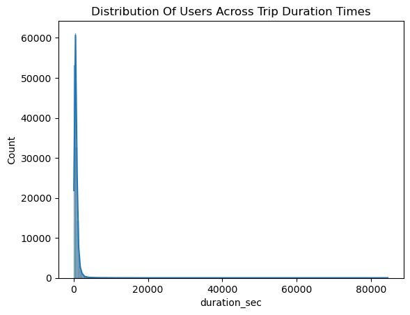

**A closer look at a smaller time duration range**

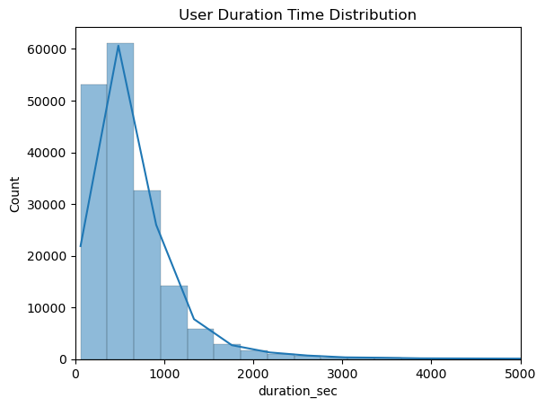

**The distribution of users in the highest bike duration range**

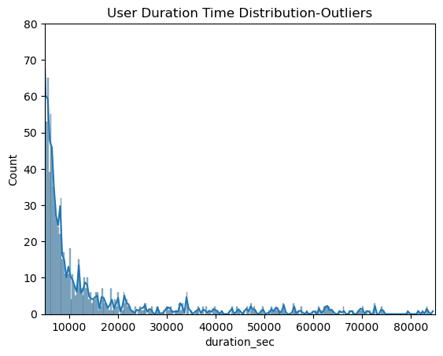

## Impact of user attributes on time duration

### Gender vs Trip Duration

Males take more longer trips than females. There is generally a high concentration of males taking trips of varying times from the shortest times to the longest times . But as trip duration increases, we tend to have fewer females. For the longest trips there are very few people and most of them are male.

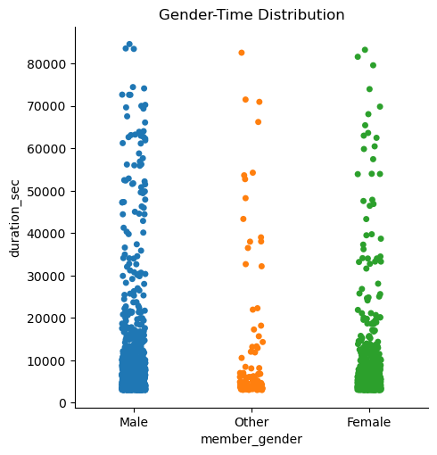

### User Type vs Trip Duration

We have a high concentration of subscribers in the longer bike duration range.As time duration increases, the concentration becomes more sparse for both user times, but mostly in customers , showing that thier numbers decrease as the time duration increases

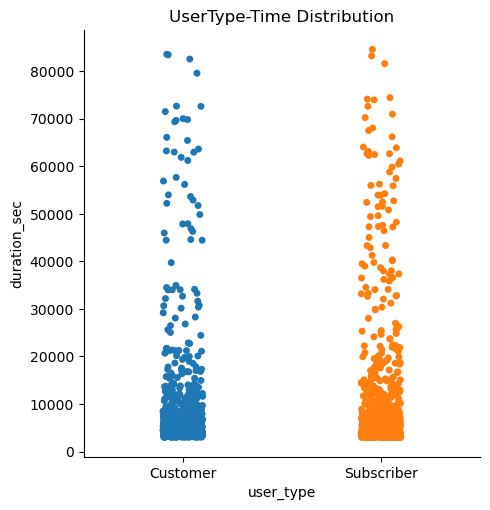

### Age Vs Trip Duration

There is no correlation between age and trip duration.Howver most of our users seem to be concentrated around ages between 25 and 40.

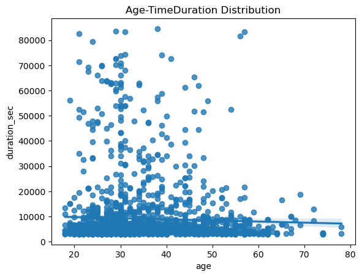

## Relationships between all the user attributes

### Gender Vs User Type Vs Trip Duration

Males overall have take longer bikes rides.This is seen by thier concentration in the time range. More male subscribers take longer bike rides

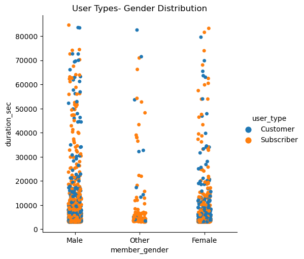

### Bike Share Option Vs Gender Vs Trip Duration Vs User Type

Female customers taking longer bike rides do not share the ride There are more male subscribers who take longer trips and dont share the rides

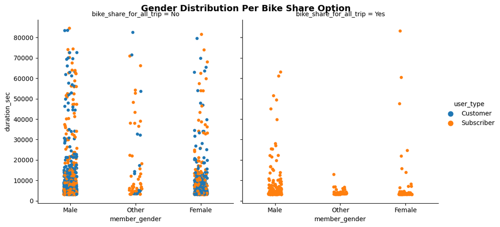